# sai_eda

Sai Rajuladevi

5/13/2021

We started by cleaning the data. The general process was to delete certain variables which did not have an effect on the predictions, like the randomized survey ID. Then we used the complete cases function which ensured that not too many NA’s got deleted to help with the data pipeline. Also, the survey data was categorized to help for better analysis.

```r
# 1
# You can use the function colnames() to apply the labels (hint: you might need to reshape the labels to make this work)
train = read_csv("train.csv")
test = read_csv("test.csv")

train.cleaned <- train[complete.cases(train), ]
train.cleaned <- train.cleaned %>% dplyr::rename_all(make.names)

test.cleaned <- test[complete.cases(test), ]
test.cleaned <- test.cleaned %>% dplyr::rename_all(make.names)

train.cleaned$satisfaction <- recode(train.cleaned$satisfaction, 'neutral or dissatisfied' = 0, 'satisfied' = 1)
test.cleaned$satisfaction <- recode(test.cleaned$satisfaction, 'neutral or dissatisfied' = 0, 'satisfied' = 1)

train.cleaned <- train.cleaned[,-c(1:6)]
test.cleaned <- test.cleaned[,-c(1:6)]

train.cleaned$Class <- as.factor(train.cleaned$Class)
test.cleaned$Class <- as.factor(test.cleaned$Class)

train.cleaned[,3:16] <- lapply(train.cleaned[,3:16], factor)

test.cleaned[,3:16] <- lapply(test.cleaned[,3:16], factor)

train.cleaned$satisfaction <- as.factor(train.cleaned$satisfaction)
test.cleaned$satisfaction <- as.factor(test.cleaned$satisfaction)


train.ready.rfr <- train.cleaned
test.ready.rfr <- test.cleaned

common <- intersect(names(train.ready.rfr), names(test.ready.rfr))

for (p in common) {
  if (class(train.ready.rfr[[p]]) == "factor")
  {
    levels(test.ready.rfr[[p]]) <- levels(train.ready.rfr[[p]])
  }
}
```

Here, we calculated the base rate, which turned out to be pretty low (around ~40%).

```r
train.ready.rfr %>%
  group_by(satisfaction) %>%
  summarise(base_rates = n() / nrow(train.ready.rfr) * 100)
```

```
## # A tibble: 2 x 2
##   satisfaction base_rates
##   <fct>             <dbl>
## 1 0                  56.7
## 2 1                  43.3
```

```r
test.ready.rfr %>%
  group_by(satisfaction) %>%
  summarise(base_rates = n() / nrow(test.ready.rfr) * 100)
```

```
## # A tibble: 2 x 2
##   satisfaction base_rates
##   <fct>             <dbl>
## 1 0                  56.1
## 2 1                  43.9
```

```r
## base rate for positive classification
base_rate_train <- 43.32
base_rate_test <- 43.89
```

A random classifier was set up, which builds multiple decision trees and merges them to create an accurate and stable prediction. The general algorithm Utilizes randomness to decorrolate the trees by splitting a random subset of features. This way, it considers only a small subset of features rather than all the features at the same time.

We then plotted the average error along the number of trees built to help with visualization.

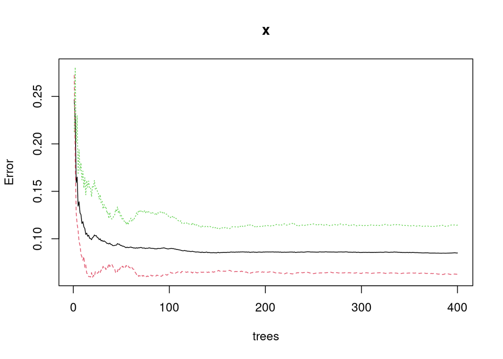

```r
#import the package
library(randomForest)
# Perform training:


set.seed(2025)
rf_classifier = randomForest(satisfaction ~ ., data=train.ready.rfr, #y = NULL,           #<- A response vector. This is unnecessary because we're specifying a response formula.
                             ntree = 400,          #<- Number of trees to grow. This should not be set to too small a number, to ensure that every input row gets classified at least a few times.
                              replace = TRUE,      #<- Should sampled data points be replaced.
                              sampsize = 200,      #<- Size of sample to draw each time.
                              nodesize = 5,        #<- Minimum numbers of data points in terminal nodes.
                              importance = TRUE,   #<- Should importance predictors be assessed?
                              proximity = FALSE,    #<- Should a proximity measure between rows be calculated?
                              norm.votes = TRUE,   #<- If TRUE (default), the final result of votes are
                              keep.forest = TRUE,  #<- If set to FALSE, the forest will not be retained in the output object. If xtest is given, defaults to FALSE.
                              keep.inbag = TRUE)

plot(rf_classifier, type="l", main=deparse(substitute(x)))
```

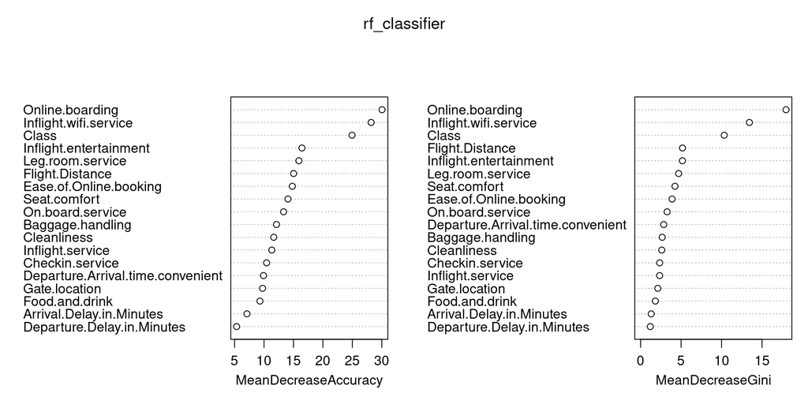

```r
varImpPlot(rf_classifier)
```

Here, we ran a confusion matrix to help show how accurate the model is on the test data.

```r
prediction_for_table <- predict(rf_classifier, test.ready.rfr[,-ncol(test.ready.rfr)])
confusionMatrix(prediction_for_table, as.factor(test.ready.rfr$satisfaction))
```

```
## Confusion Matrix and Statistics
##
##           Reference
## Prediction     0     1
##          0 13756  1788
##          1   772  9577
##
##                Accuracy : 0.9011
##                  95% CI : (0.8974, 0.9047)
##     No Information Rate : 0.5611
##     P-Value [Acc > NIR] : < 2.2e-16
##
##                   Kappa : 0.7973
##
##  Mcnemar's Test P-Value : < 2.2e-16
##
##             Sensitivity : 0.9469
##             Specificity : 0.8427
##          Pos Pred Value : 0.8850
##          Neg Pred Value : 0.9254
##              Prevalence : 0.5611
##          Detection Rate : 0.5313
##    Detection Prevalence : 0.6003
##       Balanced Accuracy : 0.8948
##
##        'Positive' Class : 0
##
```

Let’s take a look at the ROC curve.

Based on the curve, it looks like the model is a very good fit, since the curve is well above the average line.

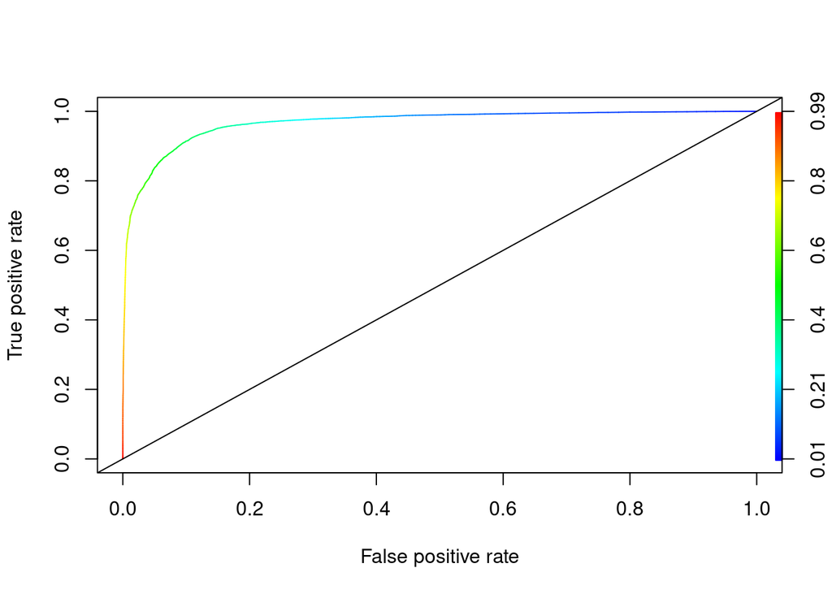

```
## integer(0)
```

```r
prediction_for_roc_curve <- predict(rf_classifier, test.ready.rfr[,-ncol(test.ready.rfr)], type="prob")

pred <- prediction(as.numeric(prediction_for_roc_curve[,"1"]), as.numeric(test.ready.rfr$satisfaction))
perf <- performance(pred,"tpr","fpr")
plot(perf,colorize=TRUE)+abline(a=0, b=1)
```

Now let’s find the AUC value. In general, an AUC of 0.5 suggests no discrimination (i.e., ability to diagnose patients with and without the disease or condition based on the test), 0.7 to 0.8 is considered acceptable, 0.8 to 0.9 is considered excellent, and more than 0.9 is considered outstanding.

In general, the AUC value tells how much the model is capable of distinguishing between classes. Higher the AUC, the better the model is at predicting satisfaction based on both specificity and sensitivity. For example, the Higher the AUC, the better the model is at distinguishing between patients with the disease and no disease.

```r
KNN_perf_AUC <- performance(pred,"auc")

paste("AUC: ", KNN_perf_AUC@y.values)
```

```
## [1] "AUC:  0.966743655408927"
```

```r
ll <- LogLoss(as.numeric(prediction_for_roc_curve[,"1"]), as.numeric(test.ready.rfr$satisfaction))
ll
```

```
## [1] 0.8180892
```

The LogLoss of the Model is 0.818-> the lower this value is the better for predictions.

Conclusion:

According to the decision tree model and the random forest model, the 3 most important factors in airline satisfaction were the satisfaction levels of online boarding, inflight wifi services, and airline classes passengers sat in. Interestingly enough, the least important factors were arrival delays and departure delays in minutes. The exploratory analysis confirmed that these factors were indeed not as important to passengers as others, which can be explained by the importance of comfort and convenience in the flight itself shown by the importance analysis from the Random Forest Model.

This can be substantiated by the fact that our metrics for accuracy, sensitivity, and specificity were high for both the decision tree and the random forest model. If the focus is to improve customer airline satisfaction, people prefer the three factors (online boarding, inflight wifi services, and airline classes) over the other factors measured in the survey, such as delay/arrival time convenience, Gate Location, and food and drinks.